# ppol563_pset1_wolfe

#### Your plot should have a legend (if necessary), descriptive title and subtitle, should not use default ggplot2 colors or the default ggplot2 theme, and all plot elements should be human readable (no overlapping text, no acronyms unless they are defined, no underscores). Axis scales should make sense and be rounded to 2 digits or less (if applicable).

**BONUS: (not required)** - change the font of the title, subtitle, and caption without removing other features of the theme.

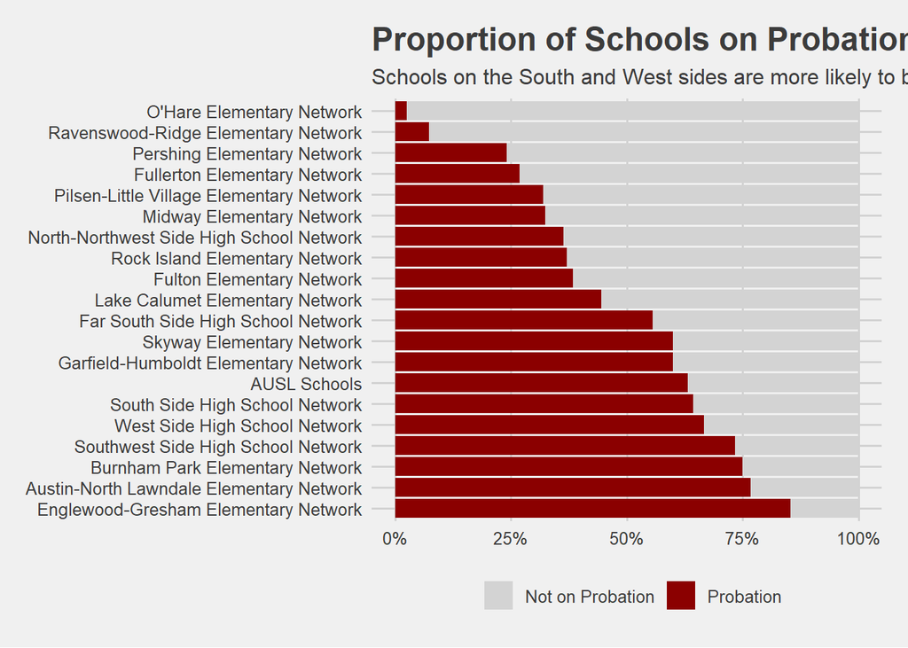

```r
# Generate barplot
d2 %>%
  drop_na(cps_performance_policy_status) %>%
  group_by(cps_performance_policy_status) %>%
  mutate(count = n()) %>%
  ggplot(aes(x=reorder(network_manager, count), fill=cps_performance_policy_status)) +
  geom_bar(position="fill", stat="count") +
  coord_flip() +
  scale_y_continuous(labels = scales::percent) +
  scale_fill_manual(values = c('lightgrey', 'darkred'), name=NULL) +
  labs(x="Name of School Network within CPS", y="Proportion of Schools", title="Proportion of Schools on Probation in Chicago Public Schools, by Network", subtitle="Schools on the South and West sides are more likely to be on probation than schools on the North side") +
  ggthemes::theme_fivethirtyeight()
```

#### 9) Create a boxplot of any numeric variable from your selected data, segmented by some relevant categorical data point. Be sure the boxplots are meaningfully sorted by some key statistic of the selected numeric variable.

#### Your plot should have a legend (if necessary), descriptive title and subtitle, should not use default ggplot2 colors or the default ggplot2 theme, and all plot elements should be human readable (no overlapping text, no acronyms unless they are defined, no underscores). Axis scales should make sense and be rounded to 2 digits or less (if applicable).

**BONUS: (not required)** - color the boxplots by the grouped median of your numeric variable.

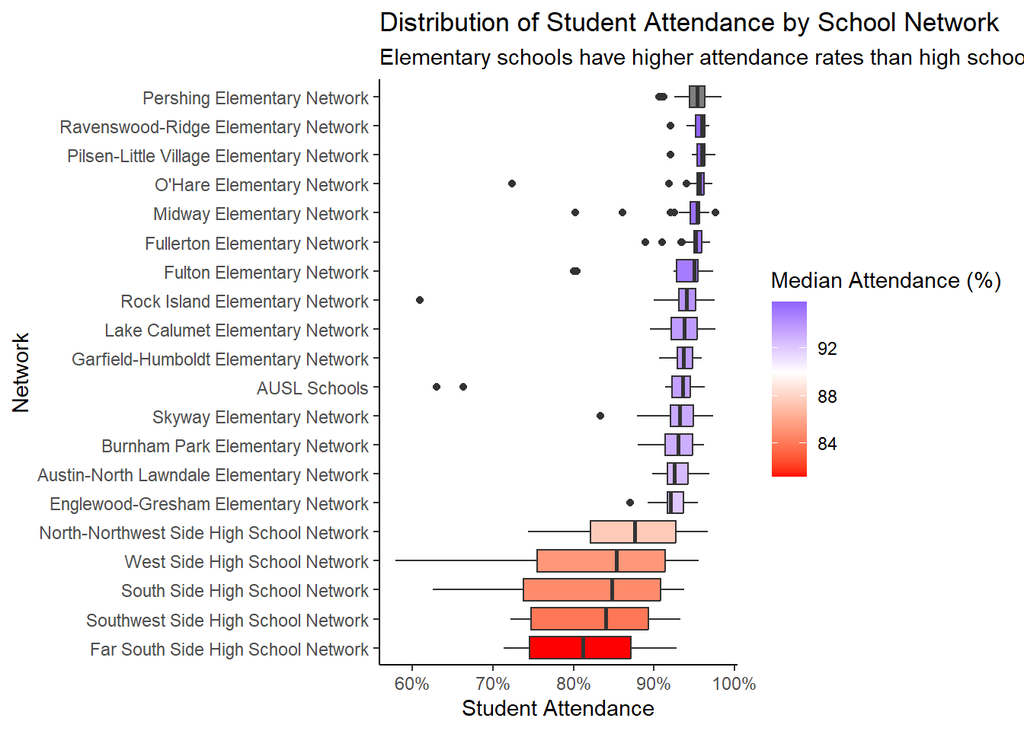

```r
d2 %>%
  group_by(network_manager) %>%
  mutate(medAttendance = median(average_student_attendance)) %>%
  ggplot(aes(x=reorder(network_manager, average_student_attendance, FUN=median), y=average_student_attendance/100)) +
  geom_boxplot(aes(fill = medAttendance)) +
  theme_classic() +
  coord_flip() +
  scale_y_continuous(labels = scales::percent) +
  scale_fill_gradient2(midpoint=90, low="red", mid="white", high="blue", space="Lab", name="Median Attendance (%)") +
  labs(x="Network", y="Student Attendance", title="Distribution of Student Attendance by School Network", subtitle="Elementary schools have higher attendance rates than high schools")
```

#### 10) Create a scatterplot using two numeric variables from the data. Use a categorical variable to highlight one category from the data. (For example, the safety_icon variable in the chicago_schools.csv data has six categories, but your visualization should only highlight one category with a color).

#### Your plot should have a legend (if necessary), descriptive title and subtitle, should not use default ggplot2 colors or the default ggplot2 theme, and all plot elements should be human readable (no overlapping text, no acronyms unless they are defined, no underscores). Axis scales should make sense and be rounded to 2 digits or less (if applicable).

**BONUS: (not required)** - add a faint dotted line that represents the average for X axis variable. Do the same for the Y axis variable.

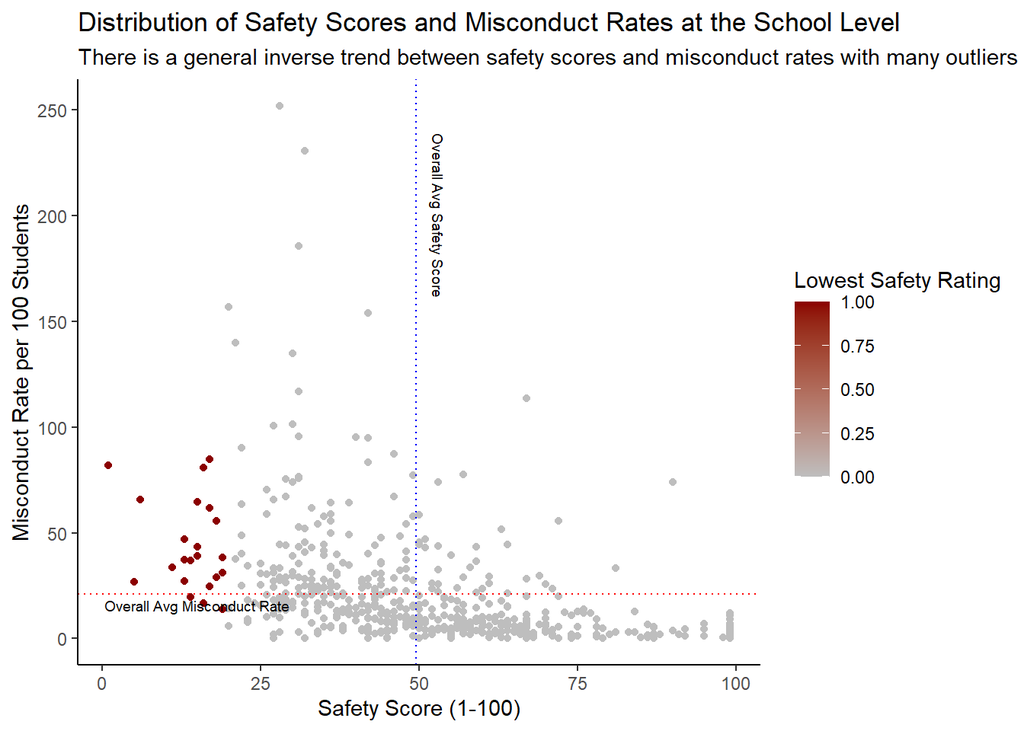

```r
# Note: mean for safety score derived from summary(d2$safety_score) and manually added to include vertical line
d2$vw_safety <- ifelse(d2$safety_icon == "Very Weak", 1, 0)
d2 %>%
  drop_na(safety_icon) %>%
  ggplot(aes(x=safety_score,y=rate_of_misconducts_per_100_students, color=vw_safety)) +
  geom_point() +
  geom_hline(yintercept=mean(d2$rate_of_misconducts_per_100_students), linetype="dotted", color="red") +
  annotate("text", x = 15, y = mean(d2$rate_of_misconducts_per_100_students), label = "Overall Avg Misconduct Rate", vjust = 1.5, size=2.5) +
  geom_vline(xintercept=49.5, linetype="dotted", color="blue") +
  annotate("text", x = 49.5, y = 200, label = "Overall Avg Safety Score", vjust = -1.5, size=2.5, angle='270') +
  theme_classic() +
  scale_color_gradient(low="grey", high="darkred", name="Lowest Safety Rating") +
  labs(x="Safety Score (1-100)", y="Misconduct Rate per 100 Students", title="Distribution of Safety Scores and Misconduct Rates at the School Level", subtitle="There is a general inverse trend between safety scores and misconduct rates with many outliers")
```